# Resultados

## Presupuesto dedicado a cultura

### Nacional

Los presupuestos nacionales aparecen contemplados en las leyes anuales de presupuesto. En la sección correspondiente a la *Exposición de Motivos* se presentan, además de los supuestos bases para la formulación presupuestaria del año, un apéndice con las estadísticas de los recursos (ingresos) y egresos de los cinco años anteriores. En el caso de los egresos, son desglosados por los siguientes conceptos y sus combinaciones:

- institución
- fuentes de financiamiento
- partidas
- conceptos principales de los egresos
- clasificación económica
- clasificación sectorial
- ámbito regional: entidades federales y municipios.

El manejo de los datos presupuestarios se realiza en base a los siguientes criterios:

1. La información contenida en las Exposiciones de Motivos se utiliza con prioridad en la investigación al resto del contenido de las leyes anuales de presupuestos. La razón estriba en que los resultados que se presentan de los cinco (5) años anteriores, contienen los presupuestos realmente ejecutados, con las modificaciones realizadas en el transcurso de cada año debido a la aprobación de créditos adicionales.
2. Como las modificaciones a las cifras presupuestarias continúan, incluso en los años siguientes al cierre del ejercicio, se prefiere utilizar las exposiciones de motivos que contengan el año de interés como el primero de la serie de cinco años. Al operar de esta forma se cuenta con cifras más estables, de modo que si el interés es presentar, por ejemplo los datos del año 1998, se opta por elegir la exposición de motivos del año 2003, porque contiene la información de los presupuestos de los cinco años anteriores, de 1998 a 2002. Es más probable que para la elaboración del proyecto de ley de presupuesto del año 2003, los datos de 1998 permanezcan sin modificaciones. Este criterio se aplica para los años de 1998 hasta 2011, luego simplemente se utiliza la última exposición de motivos publicada, es decir la del año 2016.
3. En ausencia de las exposiciones de motivos, como ha venido ocurriendo en los últimos tres años, 2017, 2018 y 2019, los datos se estiman directamente del contenido de cada ley y mediante supuestos razonables. Si bien esto limita la obtención de algunas de las clasificaciones del gasto, en especial la sectorial, al menos para el Sector 09 relativo a Cultura y Comunicación Social, fue posible obtener los datos directamente de la ONAPRE para las Entidades Federales y Municipios en el período de 2008 a 2018 y compensar la ausencia de las exposiciones de motivos de 2017 y 2018 .
4. Las unidades monetarias se estandarizan todas a miles de bolívares fuertes, moneda vigente de 2007 hasta 2018. Para ello se divide entre mil (1.000) los valores de la moneda utilizada desde el año 1879 hasta el 2007. Es innecesaria la conversión a Bolívar Soberano, vigente desde el 20 de agosto de 2018, porque los datos presupuestarios hasta ese año están expresados en bolívares fuertes. En todo caso para convertir de Bolívares fuertes a soberanos, basta con dividir a los primeros entre cien mil (100.000).

Tomando los criterios anteriores, se determina el aporte del presupuesto público a la cultura, siguiendo los pasos siguientes:

1. Identificar para cada año, las contribuciones del nivel nacional, estadal y municipal, las cuales aparecen contempladas como *Sector 09, Cultura y Comunicación Social*, en los cuadros correspondientes a la clasificación sectorial del gasto para cada uno de estos niveles.
2. Reexpresar en términos reales el valor de los presupuestos nominales que aparecen en las Exposiciones de Motivos.
3. Sumar las contribuciones de cada nivel para obtener el aporte total.

La evolución de la magnitud del aporte puede observarse comparando el presupuesto global y de cada nivel, contra el presupuesto del Sector 09.

### Magnitud relativa del presupuesto dedicado a la cultura

El presupuesto público destinado a la cultura proviene de los aportes del nivel nacional, estadal y municipal. El primer nivel corresponde a los aportes que los órganos del Poder Público Nacional y sus entes adscritos destinan al Sector 09, Cultura y Comunicación y Social. El segundo nivel lo constituyen los aportes de las Gobernaciones y el tercero los de las Alcaldías Municipales. Ahora bien, del primer nivel se transfieren recursos a los Estados y Municipios los cuales, junto a los ingresos propios de estos niveles, conforman el presupuesto de egresos de Estados y Municipios. Parte de estos recursos son destinados también al Sector 09, es decir gastos de Cultura y Comunicación Social de Gobernaciones y Alcaldías.

A partir de los datos de los cuadros 5.1.3, de la Exposición de Motivos del año 2009 [2] y los cuadros 5.1.2, 7.1 y 7.6 de la Exposición de Motivos del año 2016 [3], se construye el cuadro @ref(tab:PropPpto). Este cuadro muestra que la proporción de ingresos propios y recursos transferidos del Poder Nacional a los Estados y Municipios se ha mantenido relativamente constante a lo largo de los últimos años:

Proporción de ingresos propios vs totales de estados y municipios, años 2004-2015

| Año | Estados Ingresos.propios | Estados Ingresos.totales | Estados Proporción | Municipios Ingresos.propios.1 | Municipios Ingresos.totales.1 | Municipios Proporción.1 |
| --- | --- | --- | --- | --- | --- | --- |
| 2004 | 146196 | 10427505 | 1,40% | 3730822 | 6327111 | 58,97% |
| 2005 | 116624 | 16198927 | 0,72% | 4979846 | 8964436 | 55,55% |
| 2006 | 796107 | 26682153 | 2,98% | 7588718 | 14494791 | 52,35% |
| 2007 | 826590 | 28602581 | 2,89% | 10027853 | 17645666 | 56,83% |
| 2008 | 1359550 | 32633293 | 4,17% | 11303313 | 19766753 | 57,18% |
| 2009 | 2123670 | 36093966 | 5,88% | 14177401 | 23227442 | 61,04% |
| 2010 | 1306385 | 40202951 | 3,25% | 13916811 | 24585046 | 56,61% |
| 2011 | 2076977 | 54173326 | 3,83% | 15807338 | 29034942 | 54,44% |
| 2012 | 2170658 | 66070893 | 3,29% | 20616136 | 36387106 | 56,66% |
| 2013 | 2552316 | 98801000 | 2,58% | 26502489 | 47041625 | 56,34% |
| 2014 | 3504492 | 147114861 | 2,38% | 39733535 | 73299104 | 54,21% |
| 2015 | 3707309 | 193587476 | 1,92% | 57981080 | 107566787 | 53,90% |

La relativa estabilidad en la conformación de los presupuestos (promedios y medianas de los estados: 2,94% y 2,94%; y para los municipios: 56,17% y 56,47%) permiten seleccionar un año típico, como 2011, para mostrar con un *diagrama aluvial o de Sankey*, ver figuras @ref(fig:Aluvial1) y @ref(fig:Aluvial2), la magnitud relativa del presupuesto asignado a la cultura, del Poder Público Nacional, Regional y Municipal, incluyendo las transferencias a estas dos últimos niveles.

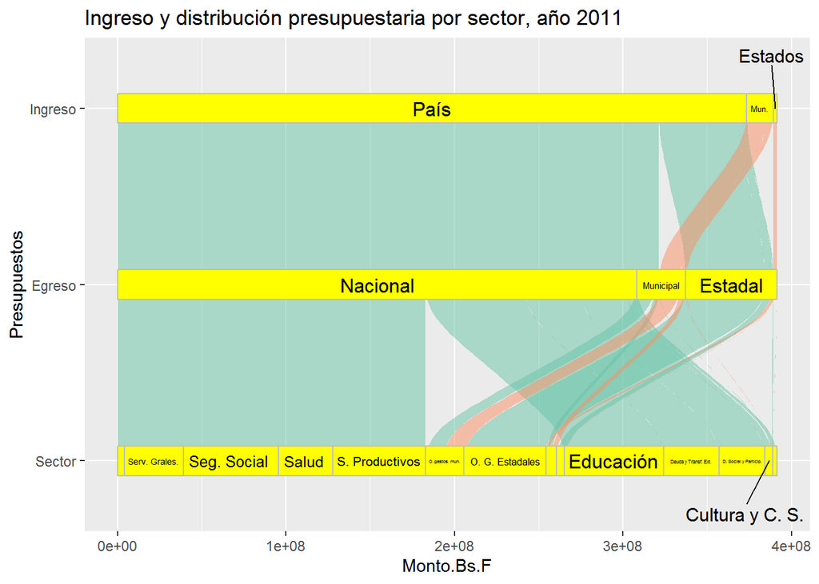

Diagrama aluvial del presupuesto nacional en 2011

O también

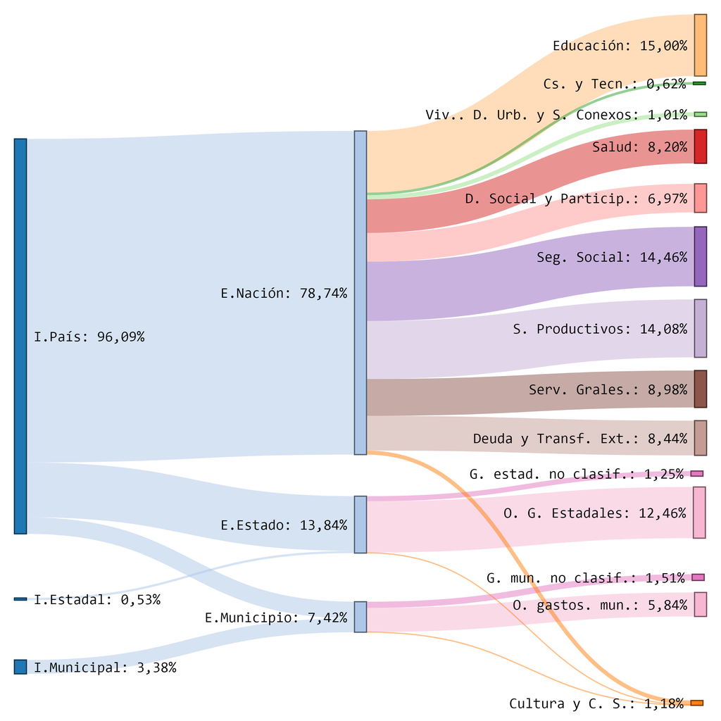

Distribución de ingresos, egresos y gastos por sector en 2011

El valor porcentual del presupuesto destinado al Sector Cultura y Comunicación Social en 2011, es de 1,18%. Como se evidencia de la figura @ref(fig:evolSector), *la proporción del presupuesto público destinada a la cultura*, (al igual que los otros sectores sociales), se mantiene estable alrededor de este valor a lo largo de los años pese a las variaciones del presupuesto público:

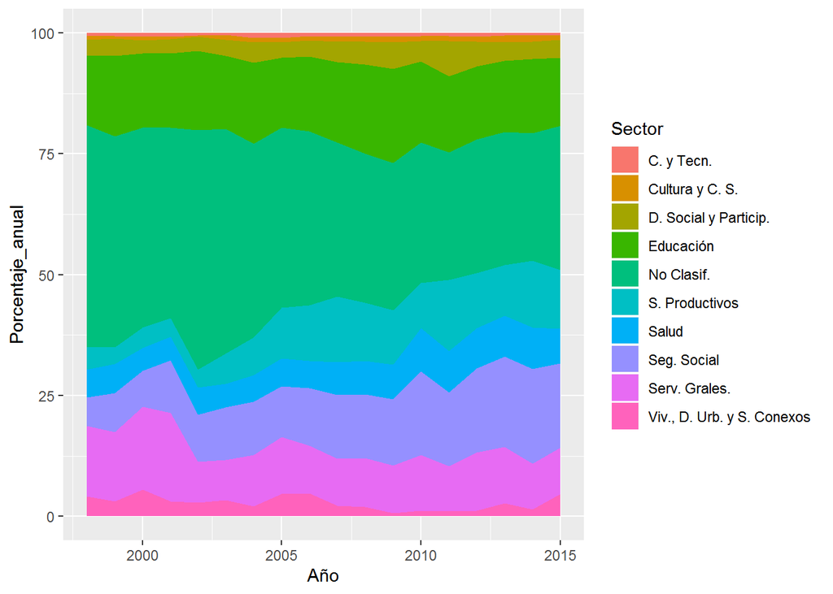

```r
library(ggplot2)
library(dplyr)
Sec_Nac <- read.csv("C:/Users/usuario/Desktop/Tesis Modelos aleatorios/Data cruda/Presupuestos/Sec_Nac.csv", sep=";",dec = ",")
Sec_Nac<-as.data.frame(Sec_Nac)
se<-ggplot(Sec_Nac, aes(x = Año, y = Porcentaje_anual, fill=Sector)) +
  geom_area()
se
```

### Reexpresión de los valores nominales del presupuesto público

Convencionalmente la reexpresión a términos reales del presupuesto público en situaciones de inflación se realiza (ver [Red-DESC](https://www.escr-net.org/es/docs/i/506523)) usando la siguiente fórmula:

$$\begin{equation}
Valor\; real= \frac{Valor\; nominal\times \;índice\; de\; inflación\; actual}{índice\; de\; inflación\; del\; año\; previo\; o\; año\; base}
\end{equation}$$

Cuando la inflación es moderada la fórmula es útil, sin embargo en situaciones de hiperinflación el índice anual, que es el acumulado a diciembre de cada año, no refleja apropiadamente la corrección, en vista de la gran variabilidad de precios de mes a mes, e incluso de un día al otro y hasta de una hora a la siguiente. La fórmula anterior seguiría siendo útil dado el caso que todo el presupuesto público se ejecutase a fines del mes de diciembre de cada año. La realidad señala en cambio, que la mayor parte del presupuesto se ejecuta mensualmente, a través de la ejecución de los llamados *dozavos*, para el pago fundamentalmente de gasto corriente, integrado por gastos de personal, suministros y servicios, es decir las partidas 4.01, 4.02 y 4.03 del clasificador presupuestario venezolano.

Ahora bien como el gasto es mensual, se puede dividir el presupuesto nominal ejecutado de cada año en doce (12) porciones correspondientes al monto ejecutado mensualmente. Luego, cada una estas porciones se reexpresan en términos reales usando la misma fórmula anterior, pero utilizando el Índice de Precios mensual en vez del anual:

$$\begin{equation}
Valor\; real\;mes_i= \frac{Valor\; nominal\;mes_i\times \;índice\; de\; inflación\; del\;mes_i}{índice\; de\; inflación\; del\; mes\, base}
\end{equation}$$

O también

$$\begin{equation}
Valor\; real\;mes_i= Valor\; nominal\;mes_i\times \;f_i\quad donde \quad i=mes=1,2,\dots,12
\end{equation}$$
con
$$\begin{equation}
f_i=\frac{índice\; de\; inflación\; del\;mes_i}{índice\; de\; inflación\; del\; mes\, base}
\end{equation}$$

Para obtener el presupuesto del año se aplicaría la siguiente fórmula:

$$\begin{equation}
Presupuesto\;real\;del\;año_j=\sum_{i=1}^{12} \frac{Presupuesto\; nominal\;del\;año_j}{12}\times \;f_i \quad con\quad j: años
\end{equation}$$

El Banco Central de Venezuela publica los actuales índices de precios al consumidor tomando el año 2008 como año base, más precisamente se fija como base 100 el índice de precios para diciembre de 2007. En esta investigación se tomará igualmente este año como base así como con todos los demás indices que se utilizan.

### Estados y Distritos

Los datos proporcionados por la ONAPRE contienen la distribución del Presupuesto de Gastos del Sector 09 “Cultura y Comunicación” en bolívares fuertes de las Entidades Federales, es decir Estados y Distritos Metropolitanos.

#### Grafico de los datos

Se realiza un gráfico boxplot con el presupuesto en valores nominales del año respectivo expresados en bolívares fuertes:

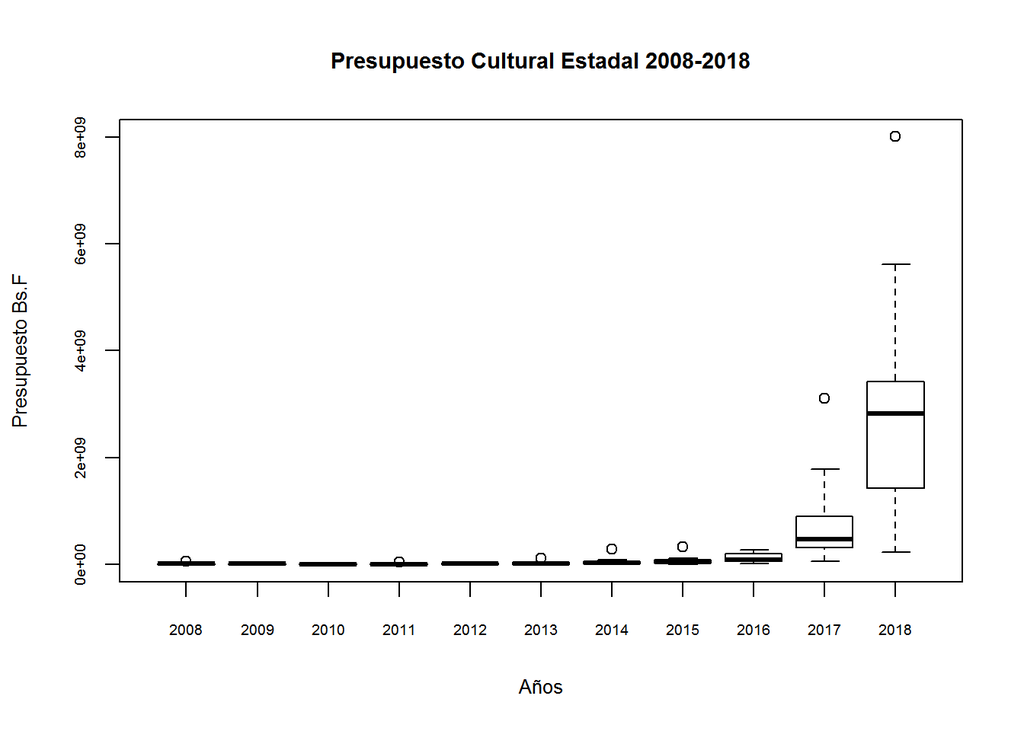

Presupuesto Cultural Estadal en términos nominales, período 2008-2018

Se observa un aparente crecimiento luego de 2016, sin embargo esto puede originarse en la devaluación de la moneda. Por tal motivo se estandarizan (escalan) los datos con respecto al promedio de cada año y se compara con el valor medio, el cual se identifica con una línea recta horizontal a trazos de color rojo:

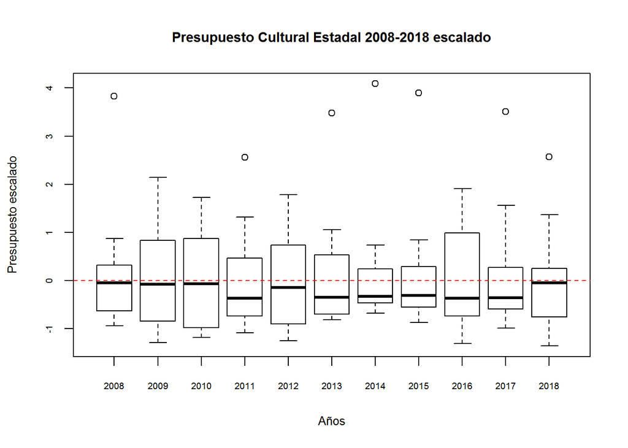

Presupuesto Cultural Estadal 2008-2018 escalado

```r
Cultura_estados_esc<-scale(Cultura_estados)
boxplot(Cultura_estados_esc,xlab="Años",
ylab="Presupuesto escalado",
main="Presupuesto Cultural Estadal 2008-2018 escalado",
cex.lab=0.8,cex.axis=0.6,cex.main=0.9)
abline(h=0,col="red",lty=2)
```

- El resultado notable para Distrito Capital y Miranda de 2013 a 2017 y en 2018 el primero, y 2008, 2009 y 2011 el segundo, es esperable en vista de la concentración cultural en la zona metropolitana de Caracas.
- Es oportuno señalar que los datos originales de la ONAPRE para los estados carecen de los datos del Distrito Capital porque este presupuesto es nacional. Los datos se recogen en el *Título IV* de las leyes anuales de presupuesto, por tanto fue necesario completar la información del Gobierno del Distrito Capital sumando los recursos destinados a la cultura a través de la Secretaría de Identidad Caraqueña y dos entes descentralizados con objetivos culturales: la Fundación Identidad Caraqueña y la Banda Marcial de Caracas.

#### Distribución de los datos

Para analizar la distribución de los datos se toman como muestras tres casos característicos: aquellos sin valores atípicos y los tres casos con los mayores valores atípicos.

La primera muestra corresponde a los años 2009, 2010 y 2012 en los cual no hubo valores atípicos. Se trazan los histogramas respectivos para ver la distribución:

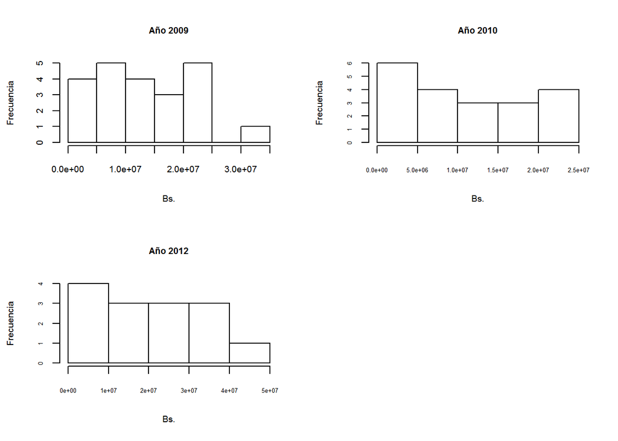

Presupuesto cultural de los estados para años sin valores atípicos

```r
par(mfrow=c(2,2))
y2009<-hist(Cultura_estados$`2009`,xlab="Bs.",
ylab="Frecuencia",
main="Año 2009", cex.lab=0.7,
cex.axis=0.7,cex.main=0.7)
y2010<-hist(Cultura_estados$`2010`,xlab="Bs.",
ylab="Frecuencia",
main="Año 2010", cex.lab=0.7,
cex.axis=0.5,cex.main=0.7)
y2012<-hist(Cultura_estados$`2012`,xlab="Bs.",
ylab="Frecuencia",
main="Año 2012", cex.lab=0.7,
cex.axis=0.5,cex.main=0.7)
```

Se observa una distribución relativamente uniforme entre los estados para estos años.

Luego, se hace lo mismo pero para los años con los mayores valores atípicos 2008, 2014 y 2015:

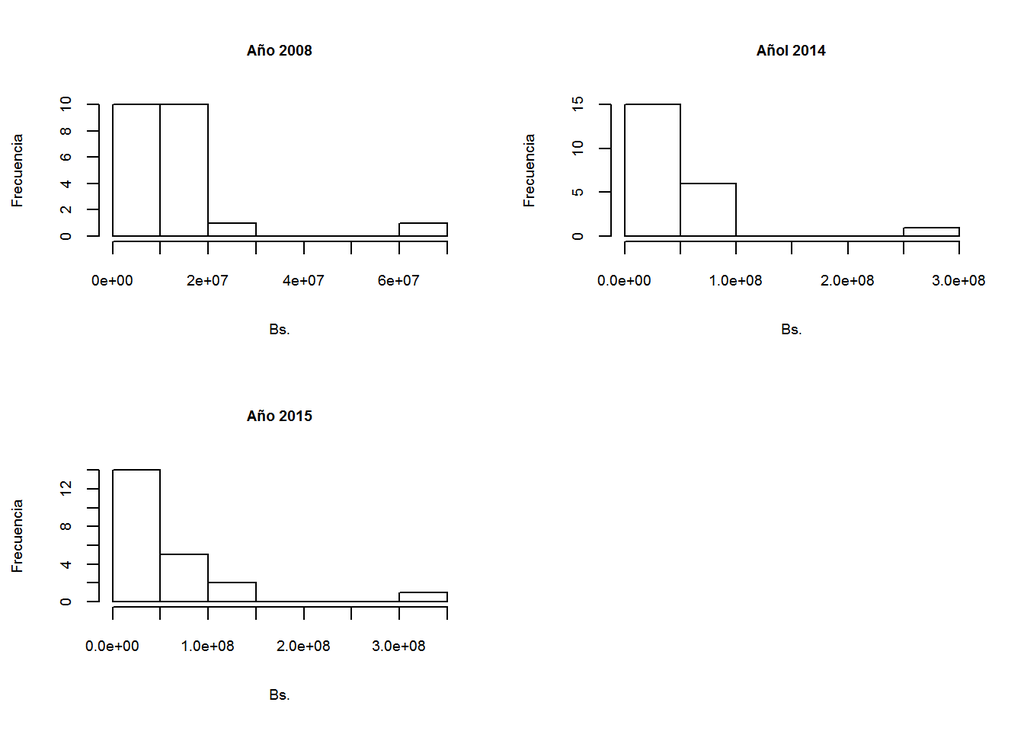

Presupuesto cultural de los estados para años con los mayores valores atípicos

```r
par(mfrow=c(2,2))
y2008<-hist(Cultura_estados$`2008`,xlab="Bs.",
ylab="Frecuencia",
main="Año 2008",
cex.lab=0.7,
cex.axis=0.7,cex.main=0.7)
y2014<-hist(Cultura_estados$`2014`,xlab="Bs.",
ylab="Frecuencia",
main="Añol 2014",
cex.lab=0.7,
cex.axis=0.7,cex.main=0.7)
y2015<-hist(Cultura_estados$`2015`,xlab="Bs.",
ylab="Frecuencia",
main="Año 2015",
cex.lab=0.7,
cex.axis=0.7,cex.main=0.7)
```

El efecto de cola larga es notable en los años con los mayores valores atípicos. Sin embargo la desigualdad no supera un primer orden de magnitud. Lo limitado de la desigualdad entre el presupuesto para la cultura estadal se debe a que como se mostró en las figuras @ref(fig:Aluvial1) y @ref(fig:Aluvial2), los recursos estadales dependen principalmente de las fuentes nacionales, vía situado constitucional o financiamientos especiales. Solo un pequeño porcentaje de los recursos estadales es derivado de los ingresos propios de los estados.

Las distribuciones de origen nacional se reparten proporcionalmente entre las 24 entidades más una proporción en función de la población. Adicionalmente, la proporción sectorial destinada a la cultura se mantiene siempre cercano al 1% del presupuesto total asignado a los estados. De allí que la desigualdad en la asignación cultural estadal, aunque existe, se limita una dispersión de solo un orden de magnitud entre los datos menores y mayores.

#### Reexpresión del presupuesto a valores reales

Otra forma de ver los datos y el cambio en el poder de compra en el período, es reexpresar los datos a valores reales, es decir constantes. Dada la limitación en la información sobre los índices inflacionarios del Banco Central de Venezuela, es posible lograr un resultado similar reexpresando los valores nominales de los bolívares fuertes de cada año en dólares. Para ello y dada la fuerte devaluación de la moneda y el inicio de un proceso hiperinflacionario en 2018, se asumirá una posición conservadora ante la variedad de tasas de cambio existentes en el período analizado. Lo importante, más que los términos absolutos, es la variación. Los criterios son los siguientes:

1. Se utiliza una única tasa para estandarizar los datos.
2. Se usa la tasa no regulada por dar una idea más realista del nivel de inflación en el período en consideración.
3. Se elige la tasa para el momento de la elaboración de los presupuestos, es decir el mes de diciembre del año anterior a la entrada en vigencia de la ley de presupuesto. Así si se trata del presupuesto de 2008, se elige la tasa para diciembre de 2007 y se continúa de la misma manera para los años siguientes hasta el 2018.

En base a los criterios anteriores se construye la matriz con los datos de las tasas de cambio (ver [Cotización histórica del bolívar con respecto al dólar](https://es.wikipedia.org/wiki/Anexo:Cotizaci%C3%B3n_hist%C3%B3rica_del_bol%C3%ADvar_con_respecto_al_d%C3%B3lar)), y se multiplica el presupuesto de cada año y estado por la tasa de cambio correspondiente:

```r
tasa<-rep(c(1/5.7,  1/5.7,  1/5.97,
1/9.14, 1/9.45, 1/17.32,
1/64.10,    1/173.0,    1/910.6,
1/3200, 1/179400),24)
Tasa<-matrix(tasa,ncol=11,byrow = TRUE)
colnames(Tasa)<-c("Tasa2008","Tasa2009","Tasa2010",
"Tasa2011","Tasa2012","Tasa2013","Tasa2014","Tasa2015",
"Tasa2016","Tasa2017","Tasa2018") #Nombres a las columnas de Tasa.
reex<-Cultura_estados*Tasa #Presupesto reexpresado en dólares USD.
```

Con los datos obtenidos anteriormente se construye el gráfico boxplot:

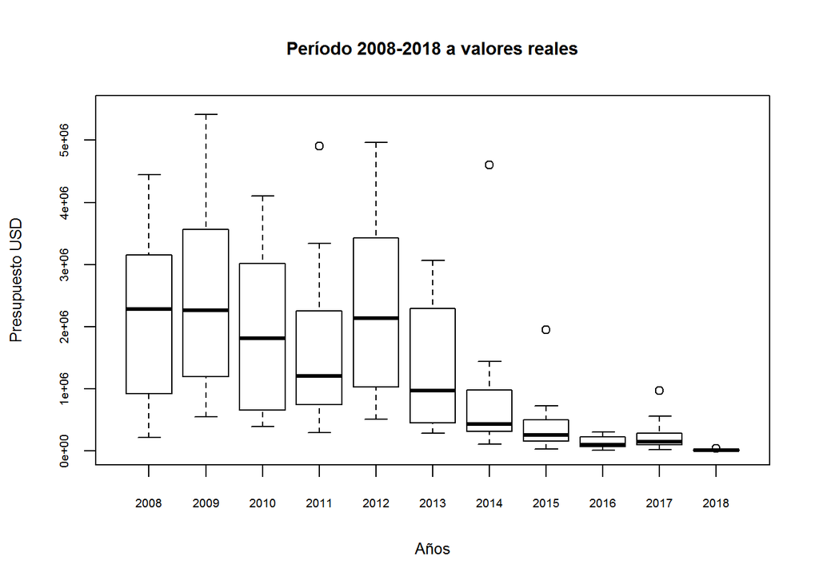

Presupuesto Cultural Estadal 2008-2018 a valores reales

```r
boxplot(reex,xlab="Años",ylab="Presupuesto USD",
main="Período 2008-2018 a valores reales",
cex.lab=0.8,cex.axis=0.6,cex.main=0.9,ylim=c(0,5500000))
```

Dada la asimetría en la distribución de los datos y la presencia de valores atípicos que afectan a la media, para comparar se elige la mediana. Se observa que la mediana se reduce aceleradamente a partir de 2013 hasta 2018. Si se comparan las medianas de cada año, tomando como base 100 al año 2008, se obtiene una representación más nítida. Para ello primero se halla la mediana de 2008 y se expresa como la base 100 y luego se divide cada valor por el valor de dicha mediana y se grafica el boxplot:

```r
m<-median(reex$`2008`,na.rm=TRUE)
m
```

```
## [1] 2284200
```

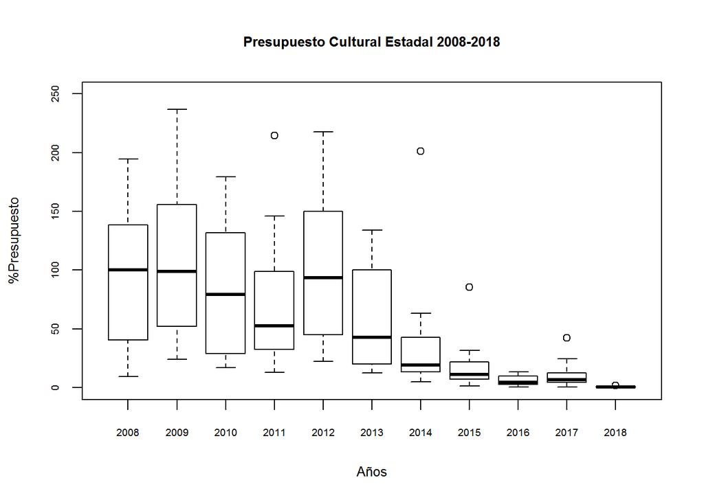

Presupuesto Cultural Estadal 2008-2018 en base a mediana de 2008

```r
reex2<-100*reex/m
boxplot(reex2,xlab="Años",
ylab="%Presupuesto",
main="Presupuesto Cultural Estadal 2008-2018",
cex.lab=0.8,cex.axis=0.6,cex.main=0.8, ylim=c(0,250))
```

Se observa una caída sostenida, y mas abrupta a partir de 2013, de una base de 100 a solo 0,5 entre 2008 y 2018 en el aporte estadal a la cultura. Una reeducción de 200 veces en el período.

[1] Puente, J.M. 2004. La economía política del gasto social en venezuela. *Revista del BCV*. 18, 1 (2004).

[2] República Bolivariana de Venezuela 2009. *Exposición de motivos del Proyecto de Ley de Presupuesto para el ejercicio económico financiero 2009*.

[3] República Bolivariana de Venezuela 2016. *Exposición de motivos del Proyecto de Ley de Presupuesto para el ejercicio económico financiero 2016*.

[^1]: El primero agrupaba los municipios Baruta, Chacao, Sucre y El Hatillo del Estado Miranda y el Municipio Libertador del Distrito Capital y el del Alto Apure a los municipios José Antonio Páez y Rómulo Gallegos del estado Apure.